Ficha del establecimiento

# Escuela Esperanza Joven

RBD **9703**La CisternaEscuela o liceo

275estudiantes matriculadosCorte Agosto 2026

Mujeres46,5%128 est.

Hombres53,5%147 est.

Chilenos/as50,2%138 est.

Extranjeros/as49,8%137 est.

Actualizada al 05-10-2026

💻Ver ficha completaVersión para computador, con mapas y gráficos interactivos. Pesa varios MB: mejor ábrela con wifi.

🏛️Identificación

## Identificación del establecimiento

Los datos de contacto y las características básicas del establecimiento, tal como están registrados en el Ministerio de Educación. **Si algo está mal o falta, escríbenos** y lo corregimos en la próxima actualización.

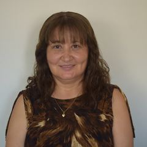

Director o directora

Fanny Del Carmen Jauregui Quezada (s)

**Nombre**

Escuela Esperanza Joven

**RBD**

9703

**Dirección**

Colon 6918

**Comuna**

La Cisterna

**Tipo**

Escuela o liceo

**Estado**

✅En funcionamiento

**Director/a**

Fanny Del Carmen Jauregui Quezada (s)

**Correo**

escuelaesperanzajoven@slepsantarosa.cl

**Teléfono**

443144708

**Sitio web**

—

**Matrícula**

GRATUITO

**Sostenedor**

El sostenedor corresponde a una persona jurídica

**Orientación**

Orientación religiosa Laica

### Niveles que imparte

✓ 🧸 Educación Parvularia✓ 🎒 Enseñanza Básica Niños

### Vulnerabilidad del alumnado

Índice de vulnerabilidad (IVE)

90,4%

Lo calcula JUNAEB y sirve para asignar programas de apoyo.

0%100%

Este establecimientoPromedio de la comuna 74%

Prioritarios en Básica

75,1%

Estudiantes en 1ª, 2ª o 3ª prioridad.

**Un IVE más alto significa más necesidad de apoyo**, no peor calidad. Se usa para decidir a qué establecimientos llegan primero los programas de alimentación, salud y becas.

### Apoyos profesionales al aprendizaje

✓ 📚 Reforzamiento✓ 🧩 Psicopedagogo/a✓ 🧠 Psicólogo/a✓ 🤝 Asistente social✓ 🗣️ Fonoaudiólogo/a🧭 Orientador/a🎓 Orientación vocacional👩‍🏫 Profesor/a de educación especial➕ Otro

### Infraestructura y atención a la diversidad

✓ 📚 Biblioteca✓ 🔬 Laboratorio✓ 🌐 Computadores con internet✓ 🖥️ Sala de informática✓ 🤾 Gimnasio✓ ♿ Accesibilidad NEE✓ ➕ Otra: SALA DE MÚSICA🏛️ Sala multiuso💻 Computadores📽️ Sala audiovisual🏟️ Cancha deportiva

Las etiquetas con ✓ son las que el establecimiento declaró en el directorio oficial; las grises no están marcadas.

### Jornada Escolar Completa (JEC)

Cursos con jornada completa

6

Cursos sin jornada completa

4

**Ver curso por curso**

| Grado | Cursos | Jornada |
| --- | --- | --- |
| 1° Básico | 1 | — Sin JEC |
| 2° Básico | 1 | — Sin JEC |
| 3° Básico | 1 | ✅ Con JEC |
| 4° Básico | 1 | ✅ Con JEC |
| 5° Básico | 1 | ✅ Con JEC |
| 6° Básico | 1 | ✅ Con JEC |
| 7° Básico | 1 | ✅ Con JEC |
| 8° Básico | 1 | ✅ Con JEC |
| Kínder | 1 | — Sin JEC |
| Pre-kínder | 1 | — Sin JEC |

Con **Jornada Escolar Completa** los estudiantes tienen más horas de clases al día y almuerzan en el establecimiento.

### Idiomas

**Inglés en Enseñanza Básica**

Básico

### Certificación ambiental (SNCAE)

🌿Certificación ambiental nivel Básico

**Inicio de la certificación**

2023

**Término de la certificación**

2025

### Concentración de alumnado prioritario

Concentración 2026

37,3%

▼13,37 pts

Porcentaje de estudiantes prioritarios reconocidos por el Mineduc.

0%100%

Concentración del establecimiento

Concentración 2025

50,7%

Resolución exenta

2026

Observación del Ministerio: **Sin ACAP 2025-2026**.

La **concentración de prioritarios** define cuánta Subvención Escolar Preferencial (SEP) recibe el establecimiento. Sobre 60 % da acceso a la asignación por concentración.

### Requisitos para postular

✓ 🎂 Cumplir la edad mínima✓ 📄 Certificado de nacimiento✓ ✍️ Firmar el proyecto educativo✓ ⚖️ Firmar el reglamento de convivencia📊 Certificado de notas📝 Informe de personalidad🏠 Ficha de protección social🧪 Test de intereses♿ Informe de necesidades educativas📋 Examen de ingreso👥 Entrevista con apoderados🎲 Sorteo💍 Certificado de matrimonio⛪ Certificado de bautismo⛪ Certificado de matrimonio religioso💰 Pago de postulación➕ Otro

Desde el Sistema de Admisión Escolar, los establecimientos públicos **no pueden seleccionar** por rendimiento ni por antecedentes socioeconómicos. Estos son los antecedentes administrativos que el establecimiento declara pedir.

**Equipo del SLEP que acompaña al establecimiento**

**Asesor/a territorial**

PILAR SOBARZO CANDIA

**Correo UTP**

utp.escuelaesperanzajoven@slepsantarosa.cl

**Correo Inspectoría**

inspectoria.escuelaesperanzajoven@slepsantarosa.cl

🏫Matrícula

## Matrícula y asistencia

Cuántos estudiantes tiene el establecimiento, quiénes son y cuántos días van efectivamente a clases. **La asistencia es el porcentaje de días que los estudiantes asistieron** sobre los días en que estuvieron matriculados.

Matrícula · Agosto 2026

275

▲1,9%

Variación desde el primer mes del año escolar.

1141.024

Este establecimientoPromedio del SLEP 333

Asistencia promedio

85,3%

Días asistidos sobre días matriculados.

22,0%98,7%

Este añoPromedio de años anteriores 81,8%

Cursos

10

Niveles

2

Matrícula regular

275

Estudiantes en la modalidad regular del establecimiento.

Matrícula no regular

0

Modalidades de adultos, reingreso o validación de estudios.

Matrícula mes a mes · 2026

Cuántos estudiantes había registrados al cierre de cada mes.

Asistencia mes a mes · 2026

Porcentaje de días asistidos sobre los días en que el estudiante estuvo matriculado.

Matrícula año a año

Matrícula del último mes de cada año escolar.

### Quiénes estudian acá

Por género

Hombres · 147Mujeres · 128

Por origen

Chilenos/as · 138Extranjeros/as · 137Nacionalizados/as · 0

Nacionalidades presentes

Número de estudiantes por país de nacimiento declarado.

🇨🇱 Chilena148

🇻🇪 Venezolana74

🌐 Otra25

🇨🇴 Colombiana13

🇵🇪 Peruana5

🇩🇴 Dominicana3

Otros7

Pueblos originarios

Estudiantes que declaran pertenecer a un pueblo originario.

🌿 Mapuche1

🏔️ Quechua1

### Por nivel de enseñanza

Matrícula por nivel

🧸 Educación Parvularia14

🎒 Enseñanza Básica Niños261

Asistencia por nivel

La escala va de 0 % a 100 %.

🧸 Educación Parvularia77,2%

🎒 Enseñanza Básica Niños85,7%

### Asistencia por grupo

Asistencia por género

Promedio ponderado por el número de estudiantes de cada grupo.

Hombres84,9%

Mujeres85,7%

Asistencia por origen

Chilenos/as82,2%

Extranjeros/as88,4%

Asistencia por nacionalidad

Solo los seis grupos con más estudiantes.

🇨🇱 Chilena84,1%

🇻🇪 Venezolana88,4%

🌐 Otra85,0%

🇨🇴 Colombiana83,9%

🇵🇪 Peruana77,1%

🇩🇴 Dominicana100,0%

Asistencia por pueblo originario

🌿 Mapuche95,2%

🏔️ Quechua0,0%

**Ver el detalle curso por curso (10 cursos)**

| Curso | Matrícula | Asistencia % |
| --- | --- | --- |
| Pre-kínder A | 9 | 75,7 |
| Kínder A | 5 | 79,8 |
| 1° Básico A | 26 | 78,6 |
| 2° Básico A | 29 | 83,9 |
| 3° Básico A | 31 | 80,8 |
| 4° Básico A | 32 | 88,2 |
| 5° Básico A | 35 | 83,9 |
| 6° Básico A | 36 | 92,3 |
| 7° Básico A | 36 | 91,1 |
| 8° Básico A | 36 | 84,1 |

**Ver la matrícula año a año, con su variación**

| Periodo | Matrícula | Variación | Cambio |
| --- | --- | --- | --- |
| 2026 | 275 | −45,0 | −14,1% |
| 2025 | 320 | +2,0 | +0,6% |
| 2024 | 318 | −4,0 | −1,2% |
| 2023 | 322 | +3,0 | +0,9% |
| 2022 | 319 | −5,0 | −1,5% |
| 2019 | 324 | +7,0 | +2,2% |
| 2018 | 317 | +37,0 | +13,2% |
| 2017 | 280 | +46,0 | +19,7% |
| 2016 | 234 | — | — |

**Ver la asistencia año a año, con su variación**

| Periodo | Asistencia | Variación | Cambio |
| --- | --- | --- | --- |
| 2026 | 85,3% | −2,4 pts | −2,7% |
| 2025 | 87,7% | −0,8 pts | −0,9% |
| 2024 | 88,5% | −0,7 pts | −0,8% |
| 2023 | 89,2% | +3,8 pts | +4,4% |
| 2022 | 85,4% | +58,1 pts | +212,8% |
| 2019 | 27,3% | −66,1 pts | −70,8% |
| 2018 | 93,4% | =0,0 pts | =0,0% |
| 2017 | 93,4% | +4,1 pts | +4,6% |
| 2016 | 89,3% | — | — |

La matrícula se cuenta al cierre de cada mes, así que los cambios durante el año reflejan traslados y retiros. Corte usado: **Agosto 2026**.

🤝Vida escolar

## Vida escolar y comunidad

Qué actividades ofrece el establecimiento fuera de las clases, cómo se organiza con las familias y quiénes representan a la comunidad. **Las etiquetas con ✓ son las que el establecimiento declaró** en el directorio oficial del Ministerio; las grises no están marcadas.

### Talleres y actividades para estudiantes

✓ 🧭 Orientación✓ 🤝 Convivencia✓ 🚫 Prevención drogas✓ ❤️ Educación sexual✓ 🌱 Medio ambiente✓ 🌟 Vida sana✓ 🫂 Acción social✝️ Pastoral➕ Otra

Actividades de formación: orientación, convivencia, prevención y vida sana.

✓ 🎭 Teatro✓ 🩰 Danza o ballet✓ 🎨 Artes plásticas✓ 💻 Taller TIC✓ ➕ Otro: TAEKWONDO📚 Literatura✂️ Manualidades🎵 Música🎓 Preuniversitario

Talleres de arte, cultura y tecnología fuera del horario de clases.

✓ 🥅 Baby fútbol✓ 🏀 Básquetbol✓ 🏓 Tenis de mesa✓ ➕ Otro: TAE KWON DO⚽ Fútbol🏃 Atletismo🏐 Vóleibol🏊 Natación🤸 Gimnasia🎾 Tenis♟️ Ajedrez

Disciplinas deportivas que ofrece el establecimiento.

### Trabajo con las familias

✓ 👪 Talleres de formación✓ 🎉 Actividades de integración📈 Perfeccionamiento➕ Otra

✓ 📒 Libreta de comunicaciones✓ 🌐 Web y redes sociales✓ 🗣️ Consejo escolar✓ 📄 Reuniones generales✓ 👥 Entrevistas individuales✓ ➕ Otro: LIRMI

Por dónde el establecimiento se comunica con apoderados y apoderadas.

### Organizaciones de la comunidad

**Centro de Padres**

Constituido

**Personalidad jurídica**

Vencida

**Última elección de directiva**

**Centro de Estudiantes**

—

**Representante del sostenedor en el Consejo Escolar**

Eiden Viera Pardo

**Acompañamiento del Consejo Escolar**

Osman Yeomans Jiménez

Para contactar al centro de padres o al centro de estudiantes, escribe al establecimiento: sus datos están más arriba.

El **Consejo Escolar** es la instancia donde se juntan dirección, docentes, asistentes, apoderados y estudiantes para conversar sobre la marcha del establecimiento.

### Normativa y conectividad

**Uso de uniforme**

Uniforme regular

**Tipo de conexión**

ADSL o cable coaxial

**Velocidad de internet**

Alta velocidad

🧭Gestión

## Instrumentos de gestión: PEI y PME

El **PEI** dice quién quiere ser el establecimiento: su misión, su visión y sus sellos. El **PME** dice qué va a hacer este año para lograrlo, con responsables y presupuesto. Son los dos documentos que ordenan el trabajo.

### Proyecto Educativo Institucional (PEI)

**Misión**

El colegio Esperanza Joven otorga una formación inclusiva e integral a estudiantes de Prebásica a Octavo Básico considerando todas las áreas del saber: humanidades, ciencias, tecnología, artes, la cultura y el deporte, lo que les permite que se desarrollen en un contexto valórico, cívico e intelectual, reflexivos y críticos.Así mismo fortalecer las habilidades de participación e innovación de la vida en comunidad, comprometidos sobre la base del derecho, la democracia y el medio ambiente enfocados en el saber convivir en la cultura del buen trato.

**Visión**

El colegio Esperanza Joven pretende que nuestros estudiantes egresen como referentes de aporte a la sociedad con valores como el respeto, tolerantes e inclusivos. Preparados en conocimientos, habilidades y destrezas para enfrentar con sabiduría la Educación Media.

### Énfasis declarados, en orden de prioridad

**1º**

Desarrollo integral

**2º**

Otro: CULTURA DEL BUEN TRATO

**3º**

Inclusivo

### Documentos oficiales

[📘Proyecto Educativo](https://wwwfs.mineduc.cl/Archivos/infoescuelas/documentos/9703/ProyectoEducativo9703.pdf)[⚖️Reglamento de Convivencia](https://wwwfs.mineduc.cl/Archivos/infoescuelas/documentos/9703/ReglamentodeConvivencia9703.pdf)[📊Reglamento de Evaluación](https://wwwfs.mineduc.cl/Archivos/infoescuelas/documentos/9703/ReglamentoDeEvaluacion9703.pdf)

### Plan de Mejoramiento Educativo (PME)

Acciones comprometidas

19

Inversión total del plan

$ 153.028.371

Dimensiones cubiertas

4

Acciones por dimensión

Las cuatro dimensiones del PME: gestión pedagógica, liderazgo, convivencia y recursos.

Gestión Pedagógica6

Liderazgo6

Convivencia Escolar4

Gestión de Recursos3

Quién lidera las acciones

Los cinco responsables con más acciones a cargo.

Equipo de gestión8

Director4

Jefe técnico3

Encargado de convivencia2

Dupla Psicosocial1

De dónde sale el financiamiento

Monto comprometido por fuente de recursos.

sep$ 153.028.371

**Ver las 19 acciones del plan**

| Acción | Dimensión | Responsable | Monto |
| --- | --- | --- | --- |
| 1. Monitoreo de Trayectoria Educativa de los estudiantes. | Gestión Pedagógica | Equipo de gestión | $ 0 |
| 2. Educación integral | Gestión Pedagógica | Director | $ 3.000.960 |
| 3. Plan de Apoyo a los Estudiantes. | Gestión Pedagógica | Jefe técnico | $ 361.840 |
| 4. Cuaderno Técnico Pedagógico | Gestión Pedagógica | Jefe técnico | $ 0 |
| 5. Acompañamiento en la Gestión Curricular a través del uso de Plataforma Educativa. | Gestión Pedagógica | Jefe técnico | $ 2.685.846 |
| 6. Transición Educativa | Gestión Pedagógica | Equipo de gestión | $ 2.922.427 |
| 7. Aprendizaje innovador | Liderazgo | Director | $ 6.962.646 |
| 8. Formando liderazgo. | Liderazgo | Director | $ 0 |
| 9. Acompañamiento a Equipos de Aula | Liderazgo | Equipo de gestión | $ 1.253.577 |
| 10. Trabajo Colaborativo para fortalecer el bienestar de los equipos educativos. | Liderazgo | Director | $ 0 |
| 11. Monitoreo y seguimiento de los resultados educativos. | Liderazgo | Equipo de gestión | $ 0 |
| 12. Monitoreo y seguimiento de los planes de gestión. | Liderazgo | Equipo de gestión | $ 0 |
| 13. Fortalecimiento del Sello Institucional. | Convivencia Escolar | Encargado de convivencia | $ 1.000.000 |
| 14. Desarrollo Personal, Social y Bienestar Emocional | Convivencia Escolar | Dupla Psicosocial | $ 0 |
| 16. Formación del Centro de Estudiantes. | Convivencia Escolar | Encargado de convivencia | $ 0 |
| 15. Participación estudiantil más allá de la escuela. | Convivencia Escolar | Equipo de gestión | $ 2.500.000 |
| 17. Administración de personal. | Gestión de Recursos | Equipo de gestión | $ 128.308.446 |
| 18. Recuros pedagógicos y de aprendizaje. | Gestión de Recursos | Equipo de gestión | $ 1.614.640 |
| 19. Servicio de multicopiado para el apoyo pedagógico. | Gestión de Recursos | Sostenedor | $ 2.417.989 |

**Ver plazos y estado de ejecución de cada acción**

| Acción | Inicio | Término | Nivel de ejecución |
| --- | --- | --- | --- |
| 1. Monitoreo de Trayectoria Educativa de los estudiantes. | 05/3/2025 | 31/12/2025 | Implementado de manera adecuada (50% a 74%) |
| 2. Educación integral | 05/3/2025 | 31/12/2025 | Implementado de manera adecuada (50% a 74%) |
| 3. Plan de Apoyo a los Estudiantes. | 05/3/2025 | 31/12/2025 | Implementado de manera adecuada (50% a 74%) |
| 4. Cuaderno Técnico Pedagógico | 05/3/2025 | 31/12/2025 | Implementado de manera adecuada (50% a 74%) |
| 5. Acompañamiento en la Gestión Curricular a través del uso de Plataforma Educativa. | 05/3/2025 | 31/12/2025 | Implementado de manera adecuada (50% a 74%) |
| 6. Transición Educativa | 05/3/2025 | 31/12/2025 | Implementado de manera adecuada (50% a 74%) |
| 7. Aprendizaje innovador | 05/3/2025 | 31/12/2025 | Implementado parcialmente (25 a 49%) |
| 8. Formando liderazgo. | 05/3/2025 | 31/12/2025 | Implementado de manera adecuada (50% a 74%) |
| 9. Acompañamiento a Equipos de Aula | 05/3/2025 | 31/12/2025 | Implementado de manera adecuada (50% a 74%) |
| 10. Trabajo Colaborativo para fortalecer el bienestar de los equipos educativos. | 05/3/2025 | 31/12/2025 | Implementado de manera adecuada (50% a 74%) |
| 11. Monitoreo y seguimiento de los resultados educativos. | 05/3/2025 | 31/12/2025 | Implementado de manera adecuada (50% a 74%) |
| 12. Monitoreo y seguimiento de los planes de gestión. | 01/3/2025 | 31/12/2025 | Implementado de manera adecuada (50% a 74%) |
| 13. Fortalecimiento del Sello Institucional. | 05/3/2025 | 31/12/2025 | Implementado de manera adecuada (50% a 74%) |
| 14. Desarrollo Personal, Social y Bienestar Emocional | 05/3/2025 | 31/12/2025 | Implementado de manera adecuada (50% a 74%) |
| 16. Formación del Centro de Estudiantes. | 05/3/2025 | 31/12/2025 | Implementación avanzada (75% a 99%) |
| 15. Participación estudiantil más allá de la escuela. | 05/3/2025 | 31/12/2025 | Implementado de manera adecuada (50% a 74%) |
| 17. Administración de personal. | 05/3/2025 | 31/12/2025 | Implementado de manera adecuada (50% a 74%) |
| 18. Recuros pedagógicos y de aprendizaje. | 05/3/2025 | 31/12/2025 | Implementado de manera adecuada (50% a 74%) |
| 19. Servicio de multicopiado para el apoyo pedagógico. | 05/3/2025 | 31/12/2025 | Implementación avanzada (75% a 99%) |

**Ver estrategia, programa y medios de verificación**

| Acción | Estrategia | Programa asociado | Medios de verificación |
| --- | --- | --- | --- |
| 1. Monitoreo de Trayectoria Educativa de los estudiantes. | Monitoreo integral de los estudiantes. | Ninguno | -Reporte de datos. -Informe uso de plataforma. -Actas de monitoreo con remediales consensuadas. |
| 2. Educación integral | Monitoreo integral de los estudiantes. | SEP | -Bitácoras de trabajo de personal de apoyo. -Bitácora uso de biblioteca. -Bitácora de uso sala de computación. |
| 3. Plan de Apoyo a los Estudiantes. | Implementacón de Plan de Apoyo a los Estudiantes. | Ninguno | -Informe de avance de los estudiantes focalizados. -Plan de Apoyo Pedagógico a los Estudiantes. |
| 4. Cuaderno Técnico Pedagógico | Implementacón de Plan de Apoyo a los Estudiantes. | Ninguno | -Cuaderno Técnico Pedagógico de los docentes. -Planilla de monitoreo del Cuaderno TP |
| 5. Acompañamiento en la Gestión Curricular a través del uso de Plataforma Educativa. | Preparación y monitoreo del proceso de enseñanza aprendizaje. | SEP | -Informe uso de plataforma. -Informes de notas. -Reportes. |
| 6. Transición Educativa | Preparación y monitoreo del proceso de enseñanza aprendizaje. | SEP | -Plan de Transición Educativa. -Actas de reuniones de Transición Educativa. |
| 7. Aprendizaje innovador | Capacitación profesional para equipos de aula. | Ninguno | -Inventario Equipamiento en apoyo pedagógico. -Inventario Recursos de Aprendizaje. |
| 8. Formando liderazgo. | Capacitación profesional para equipos de aula. | Ninguno | -Actas de registro de autocapacitaciones. |
| 9. Acompañamiento a Equipos de Aula | Sistematización de proceso de monitoreo y acompañamiento del proceso de enseñanza. | SEP | -Calendarización de acompañamiento al aula. -Plan de desarrollo profesional docente. -Pauta de acomapañamiento con retroalimentación. |
| 10. Trabajo Colaborativo para fortalecer el bienestar de los equipos educativos. | Sistematización de proceso de monitoreo y acompañamiento del proceso de enseñanza. | Ninguno | -Informe de la plataforma ADECO. -Actas de trabajo del equipo directivo. |
| 11. Monitoreo y seguimiento de los resultados educativos. | Aseguramiento un sistema de información, toma de decisiones e implementación de actividades, con foco en el uso de datos para la toma de decisiones. | Ninguno | -Actas de jornadas semestrales de evaluación de los aprendizajes. -Registro de realización de talleres de análisis de datos. |
| 12. Monitoreo y seguimiento de los planes de gestión. | Aseguramiento un sistema de información, toma de decisiones e implementación de actividades, con foco en el uso de datos para la toma de decisiones. | Ninguno | -Actas de jornadas de actualización. -Planes actualizados. |
| 13. Fortalecimiento del Sello Institucional. | Aprender a Convivir en la Cultura del Buen Trato. | SEP | -Encuesta de satisfacción semestral de estudiantes y apoderados. -Plan de Gestión de la Convivencia Educativa. |
| 14. Desarrollo Personal, Social y Bienestar Emocional | Aprender a Convivir en la Cultura del Buen Trato. | Ninguno | -Plan de Retención y Asistencia. -Acta de monitoreo de estudiantes. -Informe mensual de Dupla Psicosocial. |
| 16. Formación del Centro de Estudiantes. | Potenciación de la participación y expresión de opiniones de los estudiantes en diversas actividades escolares y extraescolares. | Ninguno | -Plan de trabajo del centro de estudiantes. -Acta de reuniones del Centro de Estudiantes. |
| 15. Participación estudiantil más allá de la escuela. | Potenciación de la participación y expresión de opiniones de los estudiantes en diversas actividades escolares y extraescolares. | SEP | -Calendarización salidas pedagógicas. |
| 17. Administración de personal. | Implementación y monitoreo de Plan de Gastos eficiente y funciones de personal contratado, para dar cumplimiento del Proyecto Educativo. | SEP | -Informe de acompañamiento y monitoreo de las funciones del personal. -Definiciones del funciones según rol y función. |
| 18. Recuros pedagógicos y de aprendizaje. | Implementación y monitoreo de Plan de Gastos eficiente y funciones de personal contratado, para dar cumplimiento del Proyecto Educativo. | SEP | -Facturas y/o recepción conforme. -Solicitudes de compra. |
| 19. Servicio de multicopiado para el apoyo pedagógico. | Implementación y monitoreo de Plan de Gastos eficiente y funciones de personal contratado, para dar cumplimiento del Proyecto Educativo. | SEP | -Registro de material impreso. -Contrato suministro. -Informe de impresiones mensuales. |

**Ver la descripción completa y la justificación de cada acción**

| Acción | Qué se hace | Por qué |
| --- | --- | --- |
| 1. Monitoreo de Trayectoria Educativa de los estudiantes. | Se realizará monitoreo multidisciplinario de los estudiantes de la escuela, con ciclos bimensuales y semestrales, con la utilización de información recabada por docentes, Equipo de Convivencia Educati… | El nivel de implementación está dentro del curso adecuado en relación a las fechas programadas. |
| 2. Educación integral | Encargado de la sala de computación, encargada de biblioteca, apoyos al aula de 1° a 4° básico, profesores de apoyo pedagógico para primer y segundo ciclo básico enriquecen el aprendizaje de los estud… | El nivel de implementación está dentro del curso adecuado en relación a las fechas programadas. |
| 3. Plan de Apoyo a los Estudiantes. | Se implementará un Plan de Apoyo a los Estudiantes con foco en aquellos que durante el año anterior aparecieron en monitoreo final como estudiantes con la necesidad de refuerzo pedagógico. Este plan i… | El nivel de implementación está dentro del curso adecuado en relación a las fechas programadas. |
| 4. Cuaderno Técnico Pedagógico | Implementación de un Cuaderno Técnico Pedagógico para que el docente registre todas las acciones que realiza con los estudiantes focalizados (entrevistas con apoderados, citaciones con apoderados, tra… | El nivel de implementación está dentro del curso adecuado en relación a las fechas programadas. |
| 5. Acompañamiento en la Gestión Curricular a través del uso de Plataforma Educativa. | Contratación de Servicio de Plataforma Educativa como herramienta que fortalezca y apoye la preparación de la enseñanza y proceso de evaluación, con el propósito de tomar decisiones de forma informada… | El nivel de implementación está dentro del curso adecuado en relación a las fechas programadas. |
| 6. Transición Educativa | Sistematización del plan de Transición Educativa entre Pre Kínder, Kínder, 1° y 2° básico, con foco en la coherencia y amabilidad del proceso educativo de estos niveles, priorizando el aula y el patio… | El nivel de implementación está dentro del curso adecuado en relación a las fechas programadas. |
| 7. Aprendizaje innovador | A través de esta acción se potenciarán espacios para el aprendizaje de innovaciones pedagógicas, a través de la utilización de recursos de aprendizaje y equipamiento de apoyo pedagógico específico por… | El nivel de implementación está dentro del curso adecuado en relación a las fechas programadas. |
| 8. Formando liderazgo. | Implementación de espacios para que docentes y asistentes lideren talleres, conversatorios y/o jornadas de reflexión, que impliquen la potenciación de los saberes profesionales, capacidades y habilida… | El nivel de implementación está dentro del curso adecuado en relación a las fechas programadas. |
| 9. Acompañamiento a Equipos de Aula | Sistematización del acompañamiento a docentes y equipos de aula, mediante la observación de clases con pauta consensuada y socializada entre los equipos, grabación de clases para análisis, realización… | El nivel de implementación está dentro del curso adecuado en relación a las fechas programadas. |
| 10. Trabajo Colaborativo para fortalecer el bienestar de los equipos educativos. | Fortalecimiento de las habilidades socioemocionales del equipo directivo para que pueda liderar y gestionar la instalación de una acción sistemática de desarrollo profesional docente que, mediante el … | El nivel de implementación está dentro del curso adecuado en relación a las fechas programadas. |
| 11. Monitoreo y seguimiento de los resultados educativos. | Sistematización del análisis de resultados educativos, académicos como formativos de la escuela, a través de jornadas de análisis de datos con equipos multidisciplinarios, para la toma de decisiones c… | El nivel de implementación está dentro del curso adecuado en relación a las fechas programadas. |
| 12. Monitoreo y seguimiento de los planes de gestión. | Actualización, implementación y socialización sistematizada y permanente de los planes de gestión de la escuela, con el fin de mantener el buen funcionamiento del establecimiento, a través de planilla… | El nivel de implementación está dentro del curso adecuado en relación a las fechas programadas. |
| 13. Fortalecimiento del Sello Institucional. | Fortalecer el sello "Aprender a Convivir en la Cultura del Buen Trato", a través de la ejecución del PGCE, con foco en la prevención de los conflictos, promoción de la snaa convivencia escolar dentro … | El nivel de implementación está dentro del curso adecuado en relación a las fechas programadas. |
| 14. Desarrollo Personal, Social y Bienestar Emocional | Sistematización del desarroll personal, social de los estudiantes, así como el bienestar emocional de toda la comunidad educativa, a través del monitoreo y seguimiento de la asistencia y atrasos, entr… | El nivel de implementación está dentro del curso adecuado en relación a las fechas programadas. |
| 16. Formación del Centro de Estudiantes. | Se realizará proceso de formación de un centro de estudiantes que sea un espacio de participación y expresión de opiniones de los niños, niñas y jóvenes de la escuela, con reuniones mensuales de la di… | El nivel de implementación está dentro del curso adecuado en relación a las fechas programadas. |
| 15. Participación estudiantil más allá de la escuela. | Fortalecimiento de la participación de estudiantes en salidas pedagógicas y actividades extraescolares como: consejo consultivo comunal, competencias comunales, talleres extracurriculares, eventos cul… | El nivel de implementación está dentro del curso adecuado en relación a las fechas programadas. |
| 17. Administración de personal. | Establecimiento claro de las funciones del recurso humano contratado, monitoreando sus funciones a través de bitácoras, informes, control de asistencia, pautas de observación, registro de actividades … | El nivel de implementación está dentro del curso adecuado en relación a las fechas programadas. |
| 18. Recuros pedagógicos y de aprendizaje. | Gestión para la adquisición de los materiales pedagógicos, didácticos y de equipamiento tecnológicos necesarios para la implementación del PME, así como para la continuidad del proceso de enseñanza ap… | El nivel de implementación está dentro del curso adecuado en relación a las fechas programadas. |
| 19. Servicio de multicopiado para el apoyo pedagógico. | Contratación de un servicio de multicopiado para la impresión de material didáctico de calidad, con el objetivo de fortalecer los pro-cesos de enseñanza y aprendizaje de los estudiantes. | El nivel de implementación está dentro del curso adecuado en relación a las fechas programadas. |

🏆SNED

## SNED · Sistema Nacional de Evaluación del Desempeño

El SNED evalúa cada dos años el desempeño de los establecimientos municipales y particulares subvencionados. Mira **seis factores**: efectividad, superación, igualdad de oportunidades, iniciativa, integración y mejoramiento.

⚪No seleccionado

Índice SNED del establecimiento

Va de 0 a 100 y resume los seis factores que evalúa el sistema.

Los seis factores, uno por uno

Cada factor va de 0 a 100. Los de arriba pesan más en el índice final.

Efectividad41,0%

Superación46,0%

Igualdad de oportunidades93,1%

Iniciativa89,0%

Integración63,5%

Mejoramiento97,3%

**¿Cuánto pesa cada factor?**

| Factor | Puntaje | Peso en el índice (%) |
| --- | --- | --- |
| Efectividad | 41 | 37 |
| Superación | 46 | 28 |
| Igualdad de oportunidades | 93,1 | 22 |
| Iniciativa | 89 | 6 |
| Integración | 63,5 | 5 |
| Mejoramiento | 97,3 | 2 |

El SNED premia con un bono a los equipos de los establecimientos con mejor desempeño dentro de un grupo de escuelas parecidas. **No es una nota**: compara con establecimientos de condiciones similares, no con todo Chile.

💼Ocupación

## Ocupación de cupos

Cuántos de los cupos que el establecimiento ofreció están efectivamente ocupados. **Se calcula dividiendo la matrícula actual por los cupos declarados** en el Sistema de Admisión Escolar (SAE).

⚠️Con cupos disponibles

Ocupación de los cupos

La marca gris señala el 100 %: por sobre esa línea hay más estudiantes que cupos declarados.

Cupos declarados (SAE)

348

Matrícula al corte

275

Agosto 2026

Cupos libres

73

Cupos que quedan sin usar.

Vacantes en el curso de ingreso

30

**Ver los cupos declarados por grado**

| Grado | Cursos | Cupos |
| --- | --- | --- |
| 1° Básico | 1 | 36 |
| 2° Básico | 1 | 36 |
| 3° Básico | 1 | 36 |
| 4° Básico | 1 | 36 |
| 5° Básico | 1 | 36 |
| 6° Básico | 1 | 36 |
| 7° Básico | 1 | 36 |
| 8° Básico | 1 | 36 |
| Kínder | 1 | 30 |
| Pre-kínder | 1 | 30 |

La ocupación compara la **matrícula efectiva** con los **cupos que el establecimiento declaró** en el Sistema de Admisión Escolar. Una ocupación baja no siempre es mala: puede ser espacio para crecer.

♿PIE

## Programa de Integración Escolar (PIE)

Cuántos estudiantes reciben apoyos del PIE y qué tipo de apoyo necesitan. Las **necesidades permanentes** acompañan toda la trayectoria escolar; las **transitorias** requieren apoyo por un tiempo determinado.

Estudiantes en PIE · 2026

38

Se cuenta cada estudiante una sola vez.

0,0%40,0%

Porcentaje de la matrícula

NEE permanentes

10

Acompañan toda la trayectoria escolar.

NEE transitorias

28

Requieren apoyo por un tiempo acotado.

Sobre la matrícula

13,8%

Tipo de necesidad educativa

NEE permanentes · 10NEE transitorias · 28

Por género

Hombres · 19Mujeres · 19

Diagnósticos más frecuentes

Los ocho diagnósticos con más estudiantes.

Trastorno del Lenguaje15

Funcionamiento Intelectual Limítrofe13

Trastorno del Espectro Autista5

Discapacidad Intelectual3

Discapacidad Motora Moderada1

Hipoacusia Severa1

En qué cursos están

5° Básico6

7° Básico6

8° Básico6

1° Básico5

2° Básico5

3° Básico4

4° Básico4

6° Básico2

Por nivel de enseñanza

Enseñanza Básica Niños38

**Ver el cruce entre género y tipo de necesidad**

| Genero | PERMANENTE | TRANSITORIO |
| --- | --- | --- |
| Femenino | 5 | 14 |
| Masculino | 5 | 14 |

**Ver el cruce entre género y los diagnósticos más frecuentes**

| Genero | Discapacidad Intelectual | Funcionamiento Intelectual Limítrofe | Trastorno del Espectro Autista | Trastorno del Lenguaje | Discapacidad Motora Moderada |
| --- | --- | --- | --- | --- | --- |
| Femenino | 2 | 7 | 3 | 7 | 0 |
| Masculino | 1 | 6 | 2 | 8 | 1 |

**Ver todos los diagnósticos registrados**

| Diagnóstico | Tipo de NEE | Estudiantes |
| --- | --- | --- |
| Trastorno del Lenguaje | TRANSITORIO | 15 |
| Funcionamiento Intelectual Limítrofe | TRANSITORIO | 13 |
| Trastorno del Espectro Autista | PERMANENTE | 5 |
| Discapacidad Intelectual | PERMANENTE | 3 |
| Discapacidad Motora Moderada | PERMANENTE | 1 |
| Hipoacusia Severa | PERMANENTE | 1 |

### Postulaciones al programa, por período

Estudiantes por año y período

El período **Regular** es la postulación anual; **Extraordinario** y **Excepcionalidad** son cupos que se abren después.

2026 · Excepcionalidad15

2026 · Regular68

2025 · Excepcionalidad9

2025 · Regular70

2024 · Regular + Excepcionalidad79

**Ver el detalle por año, período y tipo de necesidad**

| Año | Período | Tipo de NEE | Estudiantes |
| --- | --- | --- | --- |
| 2.026 | Excepcionalidad | PERMANENTE | 15 |
| 2.026 | Regular | PERMANENTE | 17 |
| 2.026 | Regular | TRANSITORIO | 51 |
| 2.025 | Excepcionalidad | PERMANENTE | 9 |
| 2.025 | Regular | PERMANENTE | 20 |
| 2.025 | Regular | TRANSITORIO | 50 |
| 2.024 | Regular + Excepcionalidad | PERMANENTE | 29 |
| 2.024 | Regular + Excepcionalidad | TRANSITORIO | 50 |

Evolución del programa

Fuente: base territorial del Área de Inclusión Educativa del SLEP.

El PIE entrega apoyos dentro del aula a estudiantes con necesidades educativas especiales. **Estar en PIE no es un diagnóstico permanente**: muchas necesidades son transitorias y se superan con apoyo.

🔄Retiros

## Retiros y movilidad estudiantil

Cuántos estudiantes se retiraron del establecimiento, cuándo y hacia dónde. **Lo importante es saber si volvieron a matricularse en otra parte**: quienes no lo hicieron son los casos que hay que buscar.

Retiros en 2026

45

Equivale al 16,4% de la matrícula actual.

Ya están en otro establecimiento

16

Se confirmó matrícula posterior.

Sin matrícula vigente

8

Requieren seguimiento: pueden estar fuera del sistema.

Pendiente en SIGE

21

Todavía sin información de destino.

En qué meses se producen

Tipo de movimiento

Sin matrícula19

Cambio a otro EE fuera del SLEP16

Cambio a otro EE pertenenciente al SLEP10

A qué establecimientos se van

Los seis destinos más frecuentes.

Sin destino informado19

Escuela Territorio Antártico4

Escuela Colegio Alberto Blest Gana2

Liceo Portal De La Cisterna2

Centro De Educacion Paula Jaraquemada1

Colegio Ellen College1

Desde qué cursos

1° Básico8

Kínder8

2° Básico6

3° Básico6

4° Básico4

5° Básico3

6° Básico3

7° Básico3

8° Básico2

Pre-kínder2

Qué tipo de establecimiento eligieron

Dependencia del establecimiento de destino.

Sin Matrícula19

Particular Subvencionado12

Mismo Slep10

Otro Slep4

A qué comunas se fueron

Sin información19

La Cisterna8

San Miguel6

San Ramón4

El Bosque1

Lo Espejo1

Loncoche1

Maipú1

**Ver todos los destinos, uno por uno**

| Establecimiento | Comuna | Dependencia | Estudiantes |
| --- | --- | --- | --- |
| Sin destino informado | — | Sin Matrícula | 19 |
| Escuela Territorio Antártico | San Miguel | Mismo Slep | 4 |
| Escuela Colegio Alberto Blest Gana | San Ramón | Particular Subvencionado | 2 |
| Liceo Portal De La Cisterna | La Cisterna | Mismo Slep | 2 |
| Centro De Educacion Paula Jaraquemada | San Ramón | Particular Subvencionado | 1 |
| Colegio Ellen College | Maipú | Particular Subvencionado | 1 |
| Colegio Especial Fundac.nuestros Hijos | San Miguel | Particular Subvencionado | 1 |
| Colegio Naciones Unidas | La Cisterna | Mismo Slep | 1 |
| Colegio Palestino | La Cisterna | Mismo Slep | 1 |
| Esc. Bas.part.francisco De Aguirre | Padre Hurtado | Particular Subvencionado | 1 |
| Escuela Araucarias | Loncoche | Otro Slep | 1 |
| Escuela Bas. Nuestra Senora Maria Inmaculada | El Bosque | Particular Subvencionado | 1 |
| Escuela Basica Nº128 San Ramon | La Cisterna | Particular Subvencionado | 1 |
| Escuela Básica F Nº 64 | Santiago | Otro Slep | 1 |
| Escuela Básica Santa Adriana | Lo Espejo | Mismo Slep | 1 |
| Escuela El Rincon | Mostazal | Otro Slep | 1 |
| Escuela Esp. Part. San Nicolas | La Cisterna | Particular Subvencionado | 1 |
| Escuela Especial El Alba De La Cisterna | La Cisterna | Particular Subvencionado | 1 |
| Escuela Especial Particular Cecla | La Cisterna | Particular Subvencionado | 1 |
| Escuela Libertad | Puerto Montt | Otro Slep | 1 |
| Escuela Particular Y Colegio Chile | San Miguel | Particular Subvencionado | 1 |
| Liceo Purkuyen | San Ramón | Mismo Slep | 1 |

Un retiro no siempre es una pérdida: muchas veces la familia se cambia de comuna. Lo que sí requiere seguimiento son los estudiantes **sin matrícula vigente** en ningún otro establecimiento.

📚Resultados

## Resultados educativos

Cómo les fue a los estudiantes en sus notas y cuántos pasaron de curso. El **promedio general** va de 1,0 a 7,0 y la **tasa de aprobación** es el porcentaje de estudiantes que fue promovido al curso siguiente.

Promedio general · 2025

6,2de 7,0

Promedio de todas las notas finales, ponderado por el tamaño de cada curso.

5,46,3

Este establecimientoPromedio del SLEP 5,9

Tasa de aprobación

99,6%

Promovidos sobre el total de estudiantes con situación final.

50%100%

Este establecimientoPromedio del SLEP 97%

Estudiantes promovidos

280

Estudiantes reprobados

1

Cómo terminó el año 2025

Situación final de cada estudiante al cierre del año escolar.

Promovidos · 280Reprobados · 1Retirados · 8Trasladados · 32

Promedio general año a año

Escala de notas de 1,0 a 7,0.

Tasa de aprobación año a año

Porcentaje de estudiantes promovidos.

**Ver el detalle por curso (8 grados)**

| Grado | Estudiantes | Promedio | Aprobación % |
| --- | --- | --- | --- |
| 1° Básico | 47 | 6,7 | 97,1 |
| 2° Básico | 39 | 6,2 | 100 |
| 3° Básico | 40 | 6,4 | 100 |
| 4° Básico | 40 | 6,1 | 100 |
| 5° Básico | 42 | 6,1 | 100 |
| 6° Básico | 38 | 6 | 100 |
| 7° Básico | 36 | 6,1 | 100 |
| 8° Básico | 39 | 6,3 | 100 |

### Aprobación por grupo

Tasa de aprobación por género

Femenino100,0%

Masculino99,3%

Tasa de aprobación por origen

Extranjero99,4%

Chileno100,0%

**Ver el promedio de notas por grupo**

| Género | Estudiantes | Promedio | Aprobación % |
| --- | --- | --- | --- |
| Femenino | 162 | 6,3 | 100 |
| Masculino | 159 | 6,1 | 99,3 |

| Origen | Estudiantes | Promedio | Aprobación % |
| --- | --- | --- | --- |
| Extranjero | 181 | 6,3 | 99,4 |
| Chileno | 140 | 6,2 | 100 |

### Cómo terminó cada año

Año 2025

Promovidos · 280Reprobados · 1Retirados · 8Trasladados · 32

Año 2024

Año 2023

Año 2022

**Ver la tabla de situación final año a año**

| Año | Promovidos | Reprobados | Retirados | Trasladados |
| --- | --- | --- | --- | --- |
| 2.025 | 280 | 1 | 8 | 32 |
| 2.024 | 277 | 0 | 8 | 20 |
| 2.023 | 272 | 0 | 20 | 23 |
| 2.022 | 266 | 0 | 12 | 29 |

**Ver el promedio y la aprobación año a año**

| Periodo | Promedio | Variación | Cambio |
| --- | --- | --- | --- |
| 2025 | 6,2 | −0,0 | −0,5% |
| 2024 | 6,3 | −0,1 | −1,1% |
| 2023 | 6,3 | −0,0 | −0,2% |
| 2022 | 6,3 | — | — |

| Periodo | Aprobación | Variación | Cambio |
| --- | --- | --- | --- |
| 2025 | 99,6% | −0,4 pts | −0,4% |
| 2024 | 100,0% | =0,0 pts | =0,0% |
| 2023 | 100,0% | =0,0 pts | =0,0% |
| 2022 | 100,0% | — | — |

La tasa de aprobación deja fuera a quienes se retiraron o se trasladaron durante el año: **solo considera a quienes terminaron el año en el establecimiento**.

📐SIMCE

## SIMCE

El SIMCE es la prueba que aplica la Agencia de Calidad para saber cuánto aprendieron los estudiantes en Lectura y Matemática. Además del puntaje, muestra **cuántos estudiantes quedaron en cada nivel de aprendizaje**: Insuficiente, Elemental o Adecuado.

### Categoría de desempeño

🚨Básica 2019: INSUFICIENTE

La categoría de desempeño la asigna la Agencia de Calidad y considera resultados **y** el contexto social del establecimiento. Va de Alto a Insuficiente.

### Resultados por curso

Última medición disponible: **2025**.

Lectura

278pts

▲30 pts

Variación respecto de la medición anterior.

233281

Última mediciónPromedio de años anteriores 243

Matemática

250pts

▲25 pts

Variación respecto de la medición anterior.

217252

Última mediciónPromedio de años anteriores 226

### ¿El cambio es real?

•Lectura ▲Sube de forma significativa•Matemática ▲Sube de forma significativa

La Agencia de Calidad indica si la diferencia con la medición anterior es **estadísticamente significativa**. Si no lo es, el cambio puede deberse al azar.

Niveles de aprendizaje · Lectura

Porcentaje de estudiantes en cada nivel de logro.

Insuficiente · 34,5%Elemental · 20,7%Adecuado · 44,8%

Niveles de aprendizaje · Matemática

Porcentaje de estudiantes en cada nivel de logro.

Insuficiente · 50,0%Elemental · 32,1%Adecuado · 17,9%

Evolución de los puntajes

Puntaje promedio del establecimiento en cada medición.

LecturaMatemática

**Comparar con establecimientos de condiciones parecidas**

| Prueba | Este establecimiento | Grupo de comparación | Diferencia |
| --- | --- | --- | --- |
| Lectura | 278 | 276 | +2 pts |
| Matemática | 250 | 260 | −10 pts |

El grupo de comparación reúne establecimientos con estudiantes de condiciones socioeconómicas similares.

**Ver todos los puntajes históricos**

| Prueba | Año | Puntaje | Estudiantes |
| --- | --- | --- | --- |
| Lectura | 2016 | 239 | 20 |
| Lectura | 2017 | 239 | 22 |
| Lectura | 2018 | 236 | 28 |
| Lectura | 2022 | 259 | 23 |
| Lectura | 2023 | 238 | 29 |
| Lectura | 2024 | 248 | 32 |
| Lectura | 2025 | 278 | — |
| Matemática | 2016 | 219 | 20 |
| Matemática | 2017 | 221 | 23 |
| Matemática | 2018 | 225 | 29 |
| Matemática | 2022 | 233 | 25 |
| Matemática | 2023 | 233 | 31 |
| Matemática | 2024 | 225 | 31 |
| Matemática | 2025 | 250 | — |

Los puntajes SIMCE van aproximadamente de 100 a 400. Una diferencia de menos de 10 puntos entre dos años **no suele ser significativa**: conviene mirar la tendencia de varios años, no el salto de uno.

🌱IDPS

## Indicadores de Desarrollo Personal y Social

Los IDPS miden cosas que no salen en una prueba: si los estudiantes se sienten capaces de aprender, si el ambiente es sano, si participan y si tienen hábitos saludables. **Van de 0 a 100** y se comparan con establecimientos de condiciones parecidas.

Última medición disponible: **2025**.

Autoestima académica y motivación escolar

82de 100

■0 pts

Variación respecto de la medición anterior.

0100

Este establecimientoEstablecimientos parecidos 74

Clima de convivencia escolar

80de 100

▲1 pts

Variación respecto de la medición anterior.

0100

Este establecimientoEstablecimientos parecidos 75

Hábitos de vida saludable

74de 100

▼1 pts

Variación respecto de la medición anterior.

0100

Este establecimientoEstablecimientos parecidos 71

Participación y formación ciudadana

88de 100

▲4 pts

Variación respecto de la medición anterior.

0100

Este establecimientoEstablecimientos parecidos 77

### ¿El cambio es real?

•Autoestima académica y motivación escolar ■Sin cambio significativo•Clima de convivencia escolar ■Sin cambio significativo•Hábitos de vida saludable ■Sin cambio significativo•Participación y formación ciudadana ▲Sube de forma significativa

Evolución de los cuatro indicadores

Autoestima académica y motivación escolarClima de convivencia escolarParticipación y formación ciudadanaHábitos de vida saludable

**Ver todos los puntajes históricos y su grupo de comparación**

| Indicador | Año | Puntaje | Grupo de comparación |
| --- | --- | --- | --- |
| Autoestima académica y motivación escolar | 2025 | 82 | 74 |
| Clima de convivencia escolar | 2025 | 80 | 75 |
| Hábitos de vida saludable | 2025 | 74 | 71 |
| Participación y formación ciudadana | 2025 | 88 | 77 |
| Autoestima académica y motivación escolar | 2024 | 82 | 74 |
| Clima de convivencia escolar | 2024 | 79 | 75 |
| Hábitos de vida saludable | 2024 | 75 | 71 |
| Participación y formación ciudadana | 2024 | 84 | 77 |
| Autoestima académica y motivación escolar | 2023 | 78 | — |
| Clima de convivencia escolar | 2023 | 82 | — |
| Hábitos de vida saludable | 2023 | 73 | — |
| Participación y formación ciudadana | 2023 | 84 | — |
| Autoestima académica y motivación escolar | 2022 | 83 | — |
| Clima de convivencia escolar | 2022 | 81 | — |
| Hábitos de vida saludable | 2022 | 83 | — |
| Participación y formación ciudadana | 2022 | 87 | — |
| Autoestima académica y motivación escolar | 2018 | 73 | — |
| Clima de convivencia escolar | 2018 | 75 | — |
| Hábitos de vida saludable | 2018 | 65 | — |
| Participación y formación ciudadana | 2018 | 79 | — |
| Autoestima académica y motivación escolar | 2017 | 72 | — |
| Clima de convivencia escolar | 2017 | 77 | — |
| Hábitos de vida saludable | 2017 | 72 | — |
| Participación y formación ciudadana | 2017 | 82 | — |
| Autoestima académica y motivación escolar | 2016 | 73 | — |
| Clima de convivencia escolar | 2016 | 74 | — |
| Hábitos de vida saludable | 2016 | 65 | — |
| Participación y formación ciudadana | 2016 | 80 | — |

Los IDPS se construyen con encuestas a estudiantes, docentes y apoderados. Van de 0 a 100 y **pesan un 33 % en la categoría de desempeño** que la Agencia de Calidad asigna al establecimiento.

📄DIA

## DIA de cierre

El Diagnóstico Integral de Aprendizajes (DIA) se aplica al cierre del año para ver qué aprendieron los estudiantes. **No pone notas**: clasifica a cada estudiante en un nivel de logro para orientar el trabajo del año siguiente.

Estudiantes evaluados

174

Aplicación 2025

En nivel 1 (inicial)

29

En nivel 2 (intermedio)

98

En nivel 3 (adecuado)

47

Cursos evaluados

6

Cómo se reparten los niveles de logro

Cuántos estudiantes quedaron en cada nivel.

Nivel 1 · inicial · 29Nivel 2 · intermedio · 98Nivel 3 · adecuado · 47

Logro promedio por eje de la prueba

Porcentaje de respuestas correctas en cada eje evaluado.

Números y operaciones61,8%

Patrones y álgebra61,5%

Geometría71,3%

Datos y probabilidades62,6%

**Ver el detalle por curso (6 cursos)**

| Curso | Estudiantes | Nivel I | Nivel II | Nivel III |
| --- | --- | --- | --- | --- |
| 3° Básico | 28 | 10 | 17 | 1 |
| 4° Básico | 29 | 4 | 12 | 13 |
| 5° Básico | 27 | 0 | 7 | 20 |
| 6° Básico | 27 | 7 | 19 | 1 |
| 7° Básico | 30 | 6 | 24 | 0 |
| 8° Básico | 33 | 2 | 19 | 12 |

El DIA es una evaluación **de diagnóstico, no una calificación**: sirve para que el equipo docente sepa dónde reforzar. Los niveles van de 1 (requiere más apoyo) a 3 (logro adecuado).

📈PAES

## PAES

La PAES es la prueba que se rinde para postular a la educación superior. Aquí verás **cuántos estudiantes la rindieron** y qué puntaje promedio obtuvieron, comparado con el promedio del SLEP y el nacional.

📭**Este establecimiento no tiene resultados PAES.**La PAES la rinden solo los establecimientos con enseñanza media.

🎓Ed. superior

## Tránsito a la educación superior

Qué pasó con los estudiantes después de egresar: cuántos entraron a una universidad, instituto profesional o centro de formación técnica, y qué estudian. **Se mira el año inmediatamente siguiente al egreso**.

📭**Todavía no hay seguimiento de egresados para este establecimiento.**El seguimiento se construye cruzando los egresados con las matrículas de educación superior.

🛠️Técnico profesional

## Técnico profesional: especialidades y titulación

Qué especialidades técnicas ofrece el establecimiento, cómo les va a los estudiantes de cada una y cuántos alcanzan el **título técnico de nivel medio** después de hacer su práctica profesional.

📭**Este establecimiento no imparte educación técnico-profesional.**Solo entrega formación humanístico-científica o de enseñanza básica.

👔Funcionarios

## Funcionarios del establecimiento

Cuántas personas trabajan en el establecimiento y en qué. La **dotación estable** son quienes tienen contrato titular o a contrata; los **reemplazos** cubren licencias y permisos, así que un número alto puede indicar rotación.

Corte: **Mayo de 2026**.

Funcionarios y funcionarias

48

Personas distintas con contrato vigente.

Dotación estable

48

Titulares y a contrata, sin contar reemplazos.

En reemplazo

0

Es el 0,0% de la dotación.

Jornada promedio

38,0hrs

Horas semanales contratadas.

Docentes y asistentes de la educación

DOCENTE25

ASISTENTE DE LA EDUCACION23

Por función

Las ocho funciones con más personas.

DOCENTES24

PROFESIONALES Y TECNICOS DE APOYO (PIE/SEP/SALUD)6

AUXILIARES DE SERVICIO4

COORDINADORES Y SOPORTE ADM.3

TECNICOS EN PARVULOS3

ADMINISTRATIVOS2

DIRECTIVOS2

EDUCADORA DE PARVULOS2

Composición de la dotación

Docentes y asistentes de la educación, estables y en reemplazo.

Docente estable · 25Asistente estable · 23

Dotación mes a mes · 2026

Número de contratos vigentes en cada mes.

Dotación mes a mes por categoría

Asistente estableDocente estable

**Ver el detalle por cargo (16 combinaciones)**

| Cargo o función | Tipo de hora | Personas | Jornada (hrs) |
| --- | --- | --- | --- |
| DOCENTES | TITULAR | 16 | 34,1 |
| DOCENTES | CONTRATA | 7 | 37,9 |
| PROFESIONALES Y TECNICOS DE APOYO (PIE/SEP/SALUD) | CODIGO DEL TRABAJO | 5 | 43,2 |
| TECNICOS EN PARVULOS | CODIGO DEL TRABAJO | 3 | 35,3 |
| AUXILIARES DE SERVICIO | CODIGO DEL TRABAJO | 2 | 44 |
| AUXILIARES DE SERVICIO | TITULAR | 2 | 44 |
| COORDINADORES Y SOPORTE ADM. | CODIGO DEL TRABAJO | 2 | 44 |
| DIRECTIVOS | TITULAR | 2 | 44 |
| EDUCADORA DE PARVULOS | TITULAR | 2 | 34,5 |
| ADMINISTRATIVOS | CODIGO DEL TRABAJO | 1 | 44 |
| ADMINISTRATIVOS | TITULAR | 1 | 32 |
| ASISTENTES DE AULA E INSPECTORIA | CODIGO DEL TRABAJO | 1 | 38 |
| COORDINADORES Y SOPORTE ADM. | CONTRATA | 1 | 44 |
| DIRECTORES | TITULAR | 1 | 34 |
| DOCENTES | CODIGO DEL TRABAJO | 1 | 44 |
| PROFESIONALES Y TECNICOS DE APOYO (PIE/SEP/SALUD) | TITULAR | 1 | 37 |

👩‍🏫Carrera docente

## Desarrollo profesional docente

En qué tramo de la Carrera Docente están los profesores y profesoras del establecimiento. Los tramos van de **Acceso** (quienes recién empiezan) a **Experto II**, y dependen de la experiencia y de la evaluación docente.

Corte: **Mayo de 2026**.

Docentes

20

En reemplazo

0

Sin encasillar

1

Es el 5,0% del cuerpo docente.

0%100%

Porcentaje sin encasillar

Docentes por tramo de la Carrera Docente

Los tramos van de Acceso (recién iniciados) a Experto II.

Acceso1

Inicial4

Temprano5

Avanzado6

Experto i3

El tramo lo asigna el Sistema de Desarrollo Profesional Docente según la experiencia y los resultados de la evaluación. **Estar sin encasillar no es una falta**: suele pasar con quienes recién ingresan o están en proceso de evaluación.

🏢Convenios

## Convenios y uso de espacios

Qué organizaciones externas usan las instalaciones del establecimiento fuera del horario de clases, para qué y hasta cuándo.

📭**No hay convenios de uso de espacios registrados.**Se registran acá los acuerdos con clubes, juntas de vecinos u otras organizaciones que usan las instalaciones.

📣Denuncias

## Denuncias y reclamos

Los reclamos que las familias y la comunidad presentaron sobre el establecimiento, por dos vías: **directamente al SLEP** o ante la **Superintendencia de Educación**, que es el organismo fiscalizador.

### Denuncias recibidas por el SLEP

No hay denuncias internas registradas para este establecimiento.

### Denuncias ante la Superintendencia de Educación

No hay denuncias ante la Superintendencia para este establecimiento.

### Procesos administrativos

No hay procesos administrativos asociados a este establecimiento.

Una denuncia **no es una sanción**: es un reclamo que se investiga. Muchas se cierran sin encontrar falta. Lo que importa es que exista el canal y que los casos se tramiten.

👮Seguridad

## Robos y delitos

Los robos y daños que ha sufrido el establecimiento, cuándo ocurrieron y cuánto costaron. **Sirve para decidir dónde reforzar la seguridad**: cámaras, cierres perimetrales o rondas.

📭**No se registran robos ni delitos en este establecimiento.**Buena noticia: no hay incidentes informados a la unidad de seguridad del SLEP.

📍Ubicación

## Ubicación y entorno

Dónde está el establecimiento, desde dónde llegan sus estudiantes y cómo es el barrio que lo rodea. **Toca el botón para abrir la ubicación** en la aplicación de mapas de tu teléfono.

**Dirección**

Colon 6918

**Comuna**

La Cisterna

**Región**

RM

**Zona**

Urbana

**Latitud**

-33,51866

**Longitud**

-70,66807

[📍Abrir en Google Maps](https://www.google.com/maps/search/?api=1&query=-33.51866183,-70.6680738)

### Dónde viven los estudiantes

Distancia promedio al colegio

2,1km

Distancia en línea recta desde el domicilio.

0,0 km15,0 km

Promedio del establecimiento

Domicilios ubicados

169

Niñas y jóvenes mujeres

2,4km

Niños y jóvenes hombres

1,9km

Estudiantes chilenos/as

1,9km

De qué comuna vienen

Misma comuna · 120Otra comuna del SLEP · 23Fuera del SLEP · 26

A qué distancia viven

Número de estudiantes en cada tramo de distancia.

Hasta 1 km107

1 a 3 km32

3 a 5 km9

Más de 5 km21

Las distancias son **en línea recta**, no el recorrido real. Se excluyen los domicilios a más de 30 km, que suelen ser errores de geocodificación. No se publican direcciones individuales.

### El barrio alrededor del establecimiento

Niños y jóvenes en la comuna

20.515

Personas de 0 a 17 años según el Censo 2024.

De 0 a 5 años

5.803

De 6 a 13 años

9.765

De 14 a 17 años

4.947

Población migrante en la comuna

19,0%

19.339 personas de 101.845 habitantes.

0%50%

Porcentaje de la comuna

Escolaridad promedio

9,6años

Años de estudio de los mayores de 18 años.

Población en edad escolar de la comuna

Censo 2024, 712 manzanas de La Cisterna.

0 a 5 años5.803

6 a 13 años9.765

14 a 17 años4.947

Estos son datos del **Censo 2024 de toda la comuna**, no del establecimiento. Sirven para dimensionar cuántos niños y jóvenes viven en el territorio.

Esta es la versión para celular, con lo esencial. La **ficha completa** tiene todas las secciones, los gráficos interactivos y los mapas; se ve mejor en un computador.

Ver ficha completa